# 1. Importing necessary libraries

## 8.10 Features and interface for desktop works as expected

```python
print("I feel that Moodle features and interfaces for desktops works as expected")
data['GOOD_DESKTOP_FEATURES_INTERFACES'].value_counts()
```

```
I feel that Moodle features and interfaces for desktops works as expected
```

```
STRONGLY_AGR     43
AGREE            26
NEUTRAL          18
STRONGLY_DISA     4
DISAGREE          1
Name: GOOD_DESKTOP_FEATURES_INTERFACES, dtype: int64
```

```python
from scipy.stats import chi2_contingency
chi2_contingency(pd.crosstab(data.Gender, data.GOOD_DESKTOP_FEATURES_INTERFACES))
```

```
(3.5159719038315806,
 0.47545394095598525,
 4,
 array([[16.67391304,  0.64130435, 11.54347826, 27.57608696,  2.56521739],
        [ 9.32608696,  0.35869565,  6.45652174, 15.42391304,  1.43478261]]))
```

```python
from scipy.stats import chi2_contingency
chi2_contingency(pd.crosstab(data.Age_Group, data.GOOD_DESKTOP_FEATURES_INTERFACES))
```

```
(15.706535817798928,
 0.04677835035128517,
 8,
 array([[19.2173913 ,  0.73913043, 13.30434783, 31.7826087 ,  2.95652174],
        [ 4.23913043,  0.16304348,  2.93478261,  7.01086957,  0.65217391],
        [ 2.54347826,  0.09782609,  1.76086957,  4.20652174,  0.39130435]]))
```

```python
from scipy.stats import chi2_contingency
chi2_contingency(pd.crosstab(data.Study_Level, data.GOOD_DESKTOP_FEATURES_INTERFACES))
```

```
(50.77240870198152,
 1.7255760970270812e-05,
 16,
 array([[13.2826087 ,  0.51086957,  9.19565217, 21.9673913 ,  2.04347826],
        [ 5.08695652,  0.19565217,  3.52173913,  8.41304348,  0.7826087 ],
        [ 5.08695652,  0.19565217,  3.52173913,  8.41304348,  0.7826087 ],
        [ 0.84782609,  0.0326087 ,  0.58695652,  1.40217391,  0.13043478],
        [ 1.69565217,  0.06521739,  1.17391304,  2.80434783,  0.26086957]]))
```

```python
from scipy.stats import chi2_contingency
chi2_contingency(pd.crosstab(data.School, data.GOOD_DESKTOP_FEATURES_INTERFACES))
```

```
(21.94102082875645,
 0.038186170356895664,
 12,
 array([[ 7.06521739,  0.27173913,  4.89130435, 11.68478261,  1.08695652],
        [ 5.36956522,  0.20652174,  3.7173913 ,  8.88043478,  0.82608696],
        [ 6.5       ,  0.25      ,  4.5       , 10.75      ,  1.        ],
        [ 7.06521739,  0.27173913,  4.89130435, 11.68478261,  1.08695652]]))
```

```python
from scipy.stats import chi2_contingency
chi2_contingency(pd.crosstab(data.Location, data.GOOD_DESKTOP_FEATURES_INTERFACES))
```

```
(34.432840200282065,
 3.390725270764166e-05,
 8,
 array([[ 1.97826087,  0.07608696,  1.36956522,  3.27173913,  0.30434783],
        [ 2.82608696,  0.10869565,  1.95652174,  4.67391304,  0.43478261],
        [21.19565217,  0.81521739, 14.67391304, 35.05434783,  3.26086957]]))
```

```python
from scipy.stats import chi2_contingency
chi2_contingency(pd.crosstab(data.Home_Computer, data.GOOD_DESKTOP_FEATURES_INTERFACES))
```

```
(8.54356298640735,
 0.0735777106514695,
 4,
 array([[11.30434783,  0.43478261,  7.82608696, 18.69565217,  1.73913043],
        [14.69565217,  0.56521739, 10.17391304, 24.30434783,  2.26086957]]))
```

```python
from scipy.stats import chi2_contingency
chi2_contingency(pd.crosstab(data.Home_Internet, data.GOOD_DESKTOP_FEATURES_INTERFACES))
```

```
(1.4692903995229578,
 0.832067007877646,
 4,
 array([[ 6.5 ,  0.25,  4.5 , 10.75,  1.  ],
        [19.5 ,  0.75, 13.5 , 32.25,  3.  ]]))
```

```python
from scipy.stats import chi2_contingency
chi2_contingency(pd.crosstab(data.Moodle_Training, data.GOOD_DESKTOP_FEATURES_INTERFACES))
```

```
(7.845127402833186,
 0.09741897919000607,
 4,
 array([[11.58695652,  0.44565217,  8.02173913, 19.16304348,  1.7826087 ],
        [14.41304348,  0.55434783,  9.97826087, 23.83695652,  2.2173913 ]]))
```

```python
from scipy.stats import chi2_contingency
chi2_contingency(pd.crosstab(data.Training_Time, data.GOOD_DESKTOP_FEATURES_INTERFACES))
```

```
(20.907747505535365,
 0.05174777499749809,
 12,
 array([[11.58695652,  0.44565217,  8.02173913, 19.16304348,  1.7826087 ],
        [ 7.91304348,  0.30434783,  5.47826087, 13.08695652,  1.2173913 ],
        [ 1.41304348,  0.05434783,  0.97826087,  2.33695652,  0.2173913 ],
        [ 5.08695652,  0.19565217,  3.52173913,  8.41304348,  0.7826087 ]]))
```

```python
from scipy.stats import chi2_contingency
chi2_contingency(pd.crosstab(data.Moodle_Access, data.GOOD_DESKTOP_FEATURES_INTERFACES))
```

```
(24.929919025849266,
 5.196870780489253e-05,
 4,
 array([[23.73913043,  0.91304348, 16.43478261, 39.26086957,  3.65217391],
        [ 2.26086957,  0.08695652,  1.56521739,  3.73913043,  0.34782609]]))
```

```python
from scipy.stats import chi2_contingency
chi2_contingency(pd.crosstab(data.Moodle_For_All, data.GOOD_DESKTOP_FEATURES_INTERFACES))
```

```
(8.179499570197246,
 0.0852198310116357,
 4,
 array([[ 6.2173913 ,  0.23913043,  4.30434783, 10.2826087 ,  0.95652174],
        [19.7826087 ,  0.76086957, 13.69565217, 32.7173913 ,  3.04347826]]))
```

```python
from scipy.stats import chi2_contingency
chi2_contingency(pd.crosstab(data.Moodle_experience, data.GOOD_DESKTOP_FEATURES_INTERFACES))
```

```
(7.867148028300992,
 0.09656776041478717,
 4,
 array([[20.06521739,  0.77173913, 13.89130435, 33.18478261,  3.08695652],
        [ 5.93478261,  0.22826087,  4.10869565,  9.81521739,  0.91304348]]))
```

## 8.11 Clearly organized

```python
print("I feel that the information on Moodle is clearly organized")
data['INFO_ORGAIZED'].value_counts()
```

```
I feel that the information on Moodle is clearly organized
```

```
STRONGLY_AGR     43
NEUTRAL          32
AGREE            14
DISAGREE          2
STRONGLY_DISA     1
Name: INFO_ORGAIZED, dtype: int64
```

```python
from scipy.stats import chi2_contingency
chi2_contingency(pd.crosstab(data.Gender, data.INFO_ORGAIZED))
```

```
(20.547851110917726,
 0.0003891938657213624,
 4,
 array([[ 8.97826087,  1.2826087 , 20.52173913, 27.57608696,  0.64130435],
        [ 5.02173913,  0.7173913 , 11.47826087, 15.42391304,  0.35869565]]))
```

```python
from scipy.stats import chi2_contingency
chi2_contingency(pd.crosstab(data.Age_Group, data.INFO_ORGAIZED))
```

```
(4.161495858033135,
 0.8422665882592119,
 8,
 array([[10.34782609,  1.47826087, 23.65217391, 31.7826087 ,  0.73913043],
        [ 2.2826087 ,  0.32608696,  5.2173913 ,  7.01086957,  0.16304348],
        [ 1.36956522,  0.19565217,  3.13043478,  4.20652174,  0.09782609]]))
```

```python
from scipy.stats import chi2_contingency
chi2_contingency(pd.crosstab(data.Study_Level, data.INFO_ORGAIZED))
```

```
(33.31331142056032,
 0.006714790882910155,
 16,
 array([[ 7.15217391,  1.02173913, 16.34782609, 21.9673913 ,  0.51086957],
        [ 2.73913043,  0.39130435,  6.26086957,  8.41304348,  0.19565217],
        [ 2.73913043,  0.39130435,  6.26086957,  8.41304348,  0.19565217],
        [ 0.45652174,  0.06521739,  1.04347826,  1.40217391,  0.0326087 ],
        [ 0.91304348,  0.13043478,  2.08695652,  2.80434783,  0.06521739]]))
```

```python
from scipy.stats import chi2_contingency
chi2_contingency(pd.crosstab(data.School, data.INFO_ORGAIZED))
```

```
(20.074617940199335,
 0.06568754258504335,
 12,
 array([[ 3.80434783,  0.54347826,  8.69565217, 11.68478261,  0.27173913],
        [ 2.89130435,  0.41304348,  6.60869565,  8.88043478,  0.20652174],
        [ 3.5       ,  0.5       ,  8.        , 10.75      ,  0.25      ],
        [ 3.80434783,  0.54347826,  8.69565217, 11.68478261,  0.27173913]]))
```

```python
from scipy.stats import chi2_contingency
chi2_contingency(pd.crosstab(data.Location, data.INFO_ORGAIZED))
```

```
(13.633958629963614,
 0.09181933086866853,
 8,
 array([[ 1.06521739,  0.15217391,  2.43478261,  3.27173913,  0.07608696],
        [ 1.52173913,  0.2173913 ,  3.47826087,  4.67391304,  0.10869565],
        [11.41304348,  1.63043478, 26.08695652, 35.05434783,  0.81521739]]))
```

```python
from scipy.stats import chi2_contingency
chi2_contingency(pd.crosstab(data.Home_Computer, data.INFO_ORGAIZED))
```

```
(2.759555488116535,
 0.598834121106099,
 4,
 array([[ 6.08695652,  0.86956522, 13.91304348, 18.69565217,  0.43478261],
        [ 7.91304348,  1.13043478, 18.08695652, 24.30434783,  0.56521739]]))
```

```python
from scipy.stats import chi2_contingency
chi2_contingency(pd.crosstab(data.Home_Internet, data.INFO_ORGAIZED))
```

```
(5.074750830564783,
 0.2797132322336839,
 4,
 array([[ 3.5 ,  0.5 ,  8.  , 10.75,  0.25],
        [10.5 ,  1.5 , 24.  , 32.25,  0.75]]))
```

```python
from scipy.stats import chi2_contingency
chi2_contingency(pd.crosstab(data.Moodle_Training, data.INFO_ORGAIZED))
```

```
(5.700072768755829,
 0.22269463724451205,
 4,
 array([[ 6.23913043,  0.89130435, 14.26086957, 19.16304348,  0.44565217],
        [ 7.76086957,  1.10869565, 17.73913043, 23.83695652,  0.55434783]]))
```

```python
from scipy.stats import chi2_contingency
chi2_contingency(pd.crosstab(data.Training_Time, data.INFO_ORGAIZED))
```

```
(29.347068834624032,
 0.0034981453553783095,
 12,
 array([[ 6.23913043,  0.89130435, 14.26086957, 19.16304348,  0.44565217],
        [ 4.26086957,  0.60869565,  9.73913043, 13.08695652,  0.30434783],
        [ 0.76086957,  0.10869565,  1.73913043,  2.33695652,  0.05434783],
        [ 2.73913043,  0.39130435,  6.26086957,  8.41304348,  0.19565217]]))
```

```python
from scipy.stats import chi2_contingency
chi2_contingency(pd.crosstab(data.Moodle_Access, data.INFO_ORGAIZED))
```

```
(9.006377551020408,
 0.0609402700569594,
 4,
 array([[12.7826087 ,  1.82608696, 29.2173913 , 39.26086957,  0.91304348],
        [ 1.2173913 ,  0.17391304,  2.7826087 ,  3.73913043,  0.08695652]]))
```

```python
from scipy.stats import chi2_contingency
chi2_contingency(pd.crosstab(data.Moodle_For_All, data.INFO_ORGAIZED))
```

```
(7.945330500064719,
 0.09360146105562585,
 4,
 array([[ 3.34782609,  0.47826087,  7.65217391, 10.2826087 ,  0.23913043],
        [10.65217391,  1.52173913, 24.34782609, 32.7173913 ,  0.76086957]]))
```

```python
from scipy.stats import chi2_contingency
chi2_contingency(pd.crosstab(data.Moodle_experience, data.INFO_ORGAIZED))
```

```
(9.610251765298322,
 0.04753045656741977,
 4,
 array([[10.80434783,  1.54347826, 24.69565217, 33.18478261,  0.77173913],
        [ 3.19565217,  0.45652174,  7.30434783,  9.81521739,  0.22826087]]))
```

## 8.12 Moodle features are not sufficient

```python
print("I feel that Moodle features are not sufficient")
data['INSUFFICIENT_FEATURES'].value_counts()
```

```
I feel that Moodle features are not sufficient
```

```
NEUTRAL          32
DISAGREE         21
STRONGLY_DISA    16
AGREE            14
STRONGLY_AGR      9
Name: INSUFFICIENT_FEATURES, dtype: int64
```

```python
from scipy.stats import chi2_contingency
chi2_contingency(pd.crosstab(data.Gender, data.INSUFFICIENT_FEATURES))
```

```
(13.644724076927465,
 0.008519688681314906,
 4,
 array([[ 8.97826087, 13.4673913 , 20.52173913,  5.77173913, 10.26086957],
        [ 5.02173913,  7.5326087 , 11.47826087,  3.22826087,  5.73913043]]))
```

```python
from scipy.stats import chi2_contingency
chi2_contingency(pd.crosstab(data.Age_Group, data.INSUFFICIENT_FEATURES))
```

```
(16.472938712522048,
 0.03608997782819683,
 8,
 array([[10.34782609, 15.52173913, 23.65217391,  6.65217391, 11.82608696],
        [ 2.2826087 ,  3.42391304,  5.2173913 ,  1.4673913 ,  2.60869565],
        [ 1.36956522,  2.05434783,  3.13043478,  0.88043478,  1.56521739]]))
```

```python
from scipy.stats import chi2_contingency
chi2_contingency(pd.crosstab(data.Study_Level, data.INSUFFICIENT_FEATURES))
```

```
(32.666457934631694,
 0.00817938341455687,
 16,
 array([[ 7.15217391, 10.72826087, 16.34782609,  4.59782609,  8.17391304],
        [ 2.73913043,  4.10869565,  6.26086957,  1.76086957,  3.13043478],
        [ 2.73913043,  4.10869565,  6.26086957,  1.76086957,  3.13043478],
        [ 0.45652174,  0.68478261,  1.04347826,  0.29347826,  0.52173913],
        [ 0.91304348,  1.36956522,  2.08695652,  0.58695652,  1.04347826]]))
```

```python
from scipy.stats import chi2_contingency
chi2_contingency(pd.crosstab(data.School, data.INSUFFICIENT_FEATURES))
```

```
(22.40741019214703,
 0.033199444002531664,
 12,
 array([[3.80434783, 5.70652174, 8.69565217, 2.44565217, 4.34782609],
        [2.89130435, 4.33695652, 6.60869565, 1.85869565, 3.30434783],
        [3.5       , 5.25      , 8.        , 2.25      , 4.        ],
        [3.80434783, 5.70652174, 8.69565217, 2.44565217, 4.34782609]]))
```

```python
from scipy.stats import chi2_contingency
chi2_contingency(pd.crosstab(data.Location, data.INSUFFICIENT_FEATURES))
```

```
(18.094115646258505,
 0.020531850136810026,
 8,
 array([[ 1.06521739,  1.59782609,  2.43478261,  0.68478261,  1.2173913 ],
        [ 1.52173913,  2.2826087 ,  3.47826087,  0.97826087,  1.73913043],
        [11.41304348, 17.11956522, 26.08695652,  7.33695652, 13.04347826]]))
```

```python
from scipy.stats import chi2_contingency
chi2_contingency(pd.crosstab(data.Home_Computer, data.INSUFFICIENT_FEATURES))
```

```
(13.053693528693529,
 0.011016396042487048,
 4,
 array([[ 6.08695652,  9.13043478, 13.91304348,  3.91304348,  6.95652174],
        [ 7.91304348, 11.86956522, 18.08695652,  5.08695652,  9.04347826]]))
```

```python
from scipy.stats import chi2_contingency
chi2_contingency(pd.crosstab(data.Home_Internet, data.INSUFFICIENT_FEATURES))
```

```
(8.015873015873016,
 0.0909984730435959,
 4,
 array([[ 3.5 ,  5.25,  8.  ,  2.25,  4.  ],
        [10.5 , 15.75, 24.  ,  6.75, 12.  ]]))
```

```python
from scipy.stats import chi2_contingency
chi2_contingency(pd.crosstab(data.Moodle_Training, data.INSUFFICIENT_FEATURES))
```

```
(12.92688240607896,
 0.011638640862185795,
 4,
 array([[ 6.23913043,  9.35869565, 14.26086957,  4.01086957,  7.13043478],
        [ 7.76086957, 11.64130435, 17.73913043,  4.98913043,  8.86956522]]))
```

```python
from scipy.stats import chi2_contingency
chi2_contingency(pd.crosstab(data.Training_Time, data.INSUFFICIENT_FEATURES))
```

```
(24.30106254109593,
 0.018505191174006678,
 12,
 array([[ 6.23913043,  9.35869565, 14.26086957,  4.01086957,  7.13043478],
        [ 4.26086957,  6.39130435,  9.73913043,  2.73913043,  4.86956522],
        [ 0.76086957,  1.14130435,  1.73913043,  0.48913043,  0.86956522],
        [ 2.73913043,  4.10869565,  6.26086957,  1.76086957,  3.13043478]]))
```

```python
from scipy.stats import chi2_contingency
chi2_contingency(pd.crosstab(data.Moodle_Access, data.INSUFFICIENT_FEATURES))
```

```
(12.923646541950113,
 0.011654959512577017,
 4,
 array([[12.7826087 , 19.17391304, 29.2173913 ,  8.2173913 , 14.60869565],
        [ 1.2173913 ,  1.82608696,  2.7826087 ,  0.7826087 ,  1.39130435]]))
```

```python
from scipy.stats import chi2_contingency
chi2_contingency(pd.crosstab(data.Moodle_For_All, data.INSUFFICIENT_FEATURES))
```

```
(13.955869923727068,
 0.007437240789132182,
 4,
 array([[ 3.34782609,  5.02173913,  7.65217391,  2.15217391,  3.82608696],
        [10.65217391, 15.97826087, 24.34782609,  6.84782609, 12.17391304]]))
```

```python
from scipy.stats import chi2_contingency
chi2_contingency(pd.crosstab(data.Moodle_experience, data.INSUFFICIENT_FEATURES))
```

```
(9.025736429156952,
 0.06045940204690364,
 4,
 array([[10.80434783, 16.20652174, 24.69565217,  6.94565217, 12.34782609],
        [ 3.19565217,  4.79347826,  7.30434783,  2.05434783,  3.65217391]]))
```

## 8.13 Moodle is mostly used to upload course materials

```python
print("I feel that Moodle is mostly used to upload course materials")
data['MOSTLY_USED_TO_UPLOAD'].value_counts()
```

```
I feel that Moodle is mostly used to upload course materials
```

```
STRONGLY_AGR     81
NEUTRAL           8
STRONGLY_DISA     2
AGREE             1
Name: MOSTLY_USED_TO_UPLOAD, dtype: int64
```

```python
from scipy.stats import chi2_contingency
chi2_contingency(pd.crosstab(data.Gender, data.MOSTLY_USED_TO_UPLOAD))
```

```
(4.042978434692182,
 0.25686047770590514,
 3,
 array([[ 0.64130435,  5.13043478, 51.94565217,  1.2826087 ],
        [ 0.35869565,  2.86956522, 29.05434783,  0.7173913 ]]))
```

```python
from scipy.stats import chi2_contingency
chi2_contingency(pd.crosstab(data.Age_Group, data.MOSTLY_USED_TO_UPLOAD))
```

```
(2.3644456548051322,
 0.8833192172573269,
 6,
 array([[ 0.73913043,  5.91304348, 59.86956522,  1.47826087],
        [ 0.16304348,  1.30434783, 13.20652174,  0.32608696],
        [ 0.09782609,  0.7826087 ,  7.92391304,  0.19565217]]))
```

```python
from scipy.stats import chi2_contingency
chi2_contingency(pd.crosstab(data.Study_Level, data.MOSTLY_USED_TO_UPLOAD))
```

```
(4.991959256340658,
 0.9582469867141018,
 12,
 array([[5.10869565e-01, 4.08695652e+00, 4.13804348e+01, 1.02173913e+00],
        [1.95652174e-01, 1.56521739e+00, 1.58478261e+01, 3.91304348e-01],
        [1.95652174e-01, 1.56521739e+00, 1.58478261e+01, 3.91304348e-01],
        [3.26086957e-02, 2.60869565e-01, 2.64130435e+00, 6.52173913e-02],
        [6.52173913e-02, 5.21739130e-01, 5.28260870e+00, 1.30434783e-01]]))
```

```python
from scipy.stats import chi2_contingency
chi2_contingency(pd.crosstab(data.School, data.MOSTLY_USED_TO_UPLOAD))
```

```
(5.291461988304093,
 0.8081966943460513,
 9,
 array([[ 0.27173913,  2.17391304, 22.01086957,  0.54347826],
        [ 0.20652174,  1.65217391, 16.72826087,  0.41304348],
        [ 0.25      ,  2.        , 20.25      ,  0.5       ],
        [ 0.27173913,  2.17391304, 22.01086957,  0.54347826]]))
```

```python
from scipy.stats import chi2_contingency
chi2_contingency(pd.crosstab(data.Location, data.MOSTLY_USED_TO_UPLOAD))
```

```
(6.083439153439152,
 0.4139084353214417,
 6,
 array([[ 0.07608696,  0.60869565,  6.16304348,  0.15217391],
        [ 0.10869565,  0.86956522,  8.80434783,  0.2173913 ],
        [ 0.81521739,  6.52173913, 66.0326087 ,  1.63043478]]))
```

```python
from scipy.stats import chi2_contingency
chi2_contingency(pd.crosstab(data.Home_Computer, data.MOSTLY_USED_TO_UPLOAD))
```

```
(2.9855769230769234,
 0.3938542808599713,
 3,
 array([[ 0.43478261,  3.47826087, 35.2173913 ,  0.86956522],
        [ 0.56521739,  4.52173913, 45.7826087 ,  1.13043478]]))
```

```python
from scipy.stats import chi2_contingency
chi2_contingency(pd.crosstab(data.Home_Internet, data.MOSTLY_USED_TO_UPLOAD))
```

```
(1.7037037037037037,
 0.6361106916550259,
 3,
 array([[ 0.25,  2.  , 20.25,  0.5 ],
        [ 0.75,  6.  , 60.75,  1.5 ]]))
```

```python
from scipy.stats import chi2_contingency
chi2_contingency(pd.crosstab(data.Moodle_Training, data.MOSTLY_USED_TO_UPLOAD))
```

```
(1.4299378287900528,
 0.698532385981341,
 3,
 array([[ 0.44565217,  3.56521739, 36.09782609,  0.89130435],
        [ 0.55434783,  4.43478261, 44.90217391,  1.10869565]]))
```

```python
from scipy.stats import chi2_contingency
chi2_contingency(pd.crosstab(data.Training_Time, data.MOSTLY_USED_TO_UPLOAD))
```

```
(4.057674108487117,
 0.9075756755064104,
 9,
 array([[ 0.44565217,  3.56521739, 36.09782609,  0.89130435],
        [ 0.30434783,  2.43478261, 24.65217391,  0.60869565],
        [ 0.05434783,  0.43478261,  4.40217391,  0.10869565],
        [ 0.19565217,  1.56521739, 15.84782609,  0.39130435]]))
```

```python
from scipy.stats import chi2_contingency
chi2_contingency(pd.crosstab(data.Moodle_Access, data.MOSTLY_USED_TO_UPLOAD))
```

```
(5.155055849500293,
 0.16078898006650494,
 3,
 array([[ 0.91304348,  7.30434783, 73.95652174,  1.82608696],
        [ 0.08695652,  0.69565217,  7.04347826,  0.17391304]]))
```

```python
from scipy.stats import chi2_contingency
chi2_contingency(pd.crosstab(data.Moodle_For_All, data.MOSTLY_USED_TO_UPLOAD))
```

```
(0.9750200416867082,
 0.8072960572333847,
 3,
 array([[ 0.23913043,  1.91304348, 19.36956522,  0.47826087],
        [ 0.76086957,  6.08695652, 61.63043478,  1.52173913]]))
```

```python
from scipy.stats import chi2_contingency
chi2_contingency(pd.crosstab(data.Moodle_experience, data.MOSTLY_USED_TO_UPLOAD))
```

```
(1.5315431684758756,
 0.6750095508471021,
 3,
 array([[ 0.77173913,  6.17391304, 62.51086957,  1.54347826],
        [ 0.22826087,  1.82608696, 18.48913043,  0.45652174]]))
```

#### The results above show us the number of responces to each perception. Also, we run the chi_squared test to check if there is any association/correlation between demographic factors and students' perceptions of the use of Moodle.

# SUMMARY

```python
df = pd.DataFrame(dict(perception=['I feel comfortable using Moodle',
                                   'I feel in need of technical support to use Moodle',
                                   'I feel that Moodle is easy to use',
                                   'I feel that Moodle is difficult to use',
                                   'I feel that Moodle is user friendly',
                                   'I feel that error messages on Moodle are helpful',
                                   'I feel that error messages on Moodle are confusing',
                                   'I feel that I am satisfied by the use of Moodle',
                                   'I feel that Moodle features and interfaces for mobile devices works as expected',
                                   'I feel that Moodle features and interfaces for desktops works as expected',
                                   'I feel that the information on Moodle is clearly organized',
                                   'I feel that Moodle features are not sufficient',
                                   'I feel that Moodle is mostly used to upload course materials'],

                        S_Agree = [55, 4, 59, 0, 43, 19, 3,  42, 39, 43, 43, 9, 81],
                          Agree = [27, 7, 22, 3, 27, 18, 9,  28, 26, 26, 14, 14, 1],
                        Neutral = [7, 38, 11, 1, 21, 39, 37, 17, 15, 18, 32, 32, 8],
                       Disagree = [0, 14, 0, 17, 0,  13, 17, 0,  4,  1,  2,  21, 0],
                     S_Disagree = [3, 29, 0, 71, 1,  3,  26, 5,  8,  4,  1,  16, 2]))

df
```

|  | perception | S_Agree | Agree | Neutral | Disagree | S_Disagree |
| --- | --- | --- | --- | --- | --- | --- |
| 0 | I feel comfortable using Moodle | 55 | 27 | 7 | 0 | 3 |
| 1 | I feel in need of technical support to use Moodle | 4 | 7 | 38 | 14 | 29 |
| 2 | I feel that Moodle is easy to use | 59 | 22 | 11 | 0 | 0 |
| 3 | I feel that Moodle is difficult to use | 0 | 3 | 1 | 17 | 71 |
| 4 | I feel that Moodle is user friendly | 43 | 27 | 21 | 0 | 1 |
| 5 | I feel that error messages on Moodle are helpful | 19 | 18 | 39 | 13 | 3 |
| 6 | I feel that error messages on Moodle are confu... | 3 | 9 | 37 | 17 | 26 |
| 7 | I feel that I am satisfied by the use of Moodle | 42 | 28 | 17 | 0 | 5 |
| 8 | I feel that Moodle features and interfaces for... | 39 | 26 | 15 | 4 | 8 |
| 9 | I feel that Moodle features and interfaces for... | 43 | 26 | 18 | 1 | 4 |
| 10 | I feel that the information on Moodle is clear... | 43 | 14 | 32 | 2 | 1 |
| 11 | I feel that Moodle features are not sufficient | 9 | 14 | 32 | 21 | 16 |
| 12 | I feel that Moodle is mostly used to upload co... | 81 | 1 | 8 | 0 | 2 |

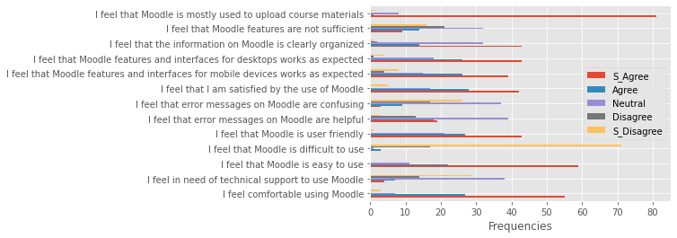

```python
answers = {'S_Agree': [55, 4, 59, 0, 43, 19, 3, 42, 39, 43, 43, 9, 81],
        'Agree': [27, 7, 22, 3, 27, 18, 9, 28, 26, 26, 14, 14, 1],
        'Neutral': [7, 38, 11, 1, 21, 39, 37, 17, 15, 18, 32, 32, 8],
        'Disagree': [0, 14, 0, 17, 0, 13, 17, 0, 4, 1, 2, 21, 0],
        'S_Disagree': [3, 29, 0, 71, 1, 3, 26, 5, 8, 4, 1, 16, 2]
       }
df = pd.DataFrame(answers, columns=['S_Agree', 'Agree', 'Neutral', 'Disagree', 'S_Disagree' ],
index = ['I feel comfortable using Moodle',
         'I feel in need of technical support to use Moodle',
         'I feel that Moodle is easy to use',
         'I feel that Moodle is difficult to use',
         'I feel that Moodle is user friendly',
         'I feel that error messages on Moodle are helpful',
         'I feel that error messages on Moodle are confusing',
         'I feel that I am satisfied by the use of Moodle',
         'I feel that Moodle features and interfaces for mobile devices works as expected',
         'I feel that Moodle features and interfaces for desktops works as expected',
         'I feel that the information on Moodle is clearly organized',
         'I feel that Moodle features are not sufficient',
         'I feel that Moodle is mostly used to upload course materials'])

plt.style.use('ggplot')
df.plot.barh()
plt.xlabel('Frequencies')
plt.show()
```

# 9 Benefits of the use of Moodle

## 9.1 Accessible anytime, anywhere

```python
print("Accessible anytime, anywhere")
data['ANYTIME_ACCESS'].value_counts()
```

```
Accessible anytime, anywhere
```

```
STRONGLY_AGR     43
NEUTRAL          18
AGREE            17
STRONGLY_DISA    13
DISAGREE          1
Name: ANYTIME_ACCESS, dtype: int64
```

#### The outputs above are telling us about the number of respondents who are disagreeing with the statement about Moodle accessability.

## 9.2 Ease and quick sharing

```python
print("Ease and quick sharing of course materials")
data['EASE_AND_QUICK_SHARING'].value_counts()
```

```
Ease and quick sharing of course materials
```

```
STRONGLY_AGR     58
AGREE            17
NEUTRAL          16
STRONGLY_DISA     1
Name: EASE_AND_QUICK_SHARING, dtype: int64
```

## 9.3 Learn at own pace

```python
print("Allow students to learn at their own pace")
data['OWN_PACE_LEARNING'].value_counts()
```

```
Allow students to learn at their own pace
```

```
STRONGLY_AGR    48
NEUTRAL         29
AGREE           11
DISAGREE         4
Name: OWN_PACE_LEARNING, dtype: int64
```

## 9.4 Improved interaction and collaboration

```python
print("Improved interaction and collaboration between student, lecturers, and tutor")
data['STU_LEC_TUT_INTERACT'].value_counts()
```

```
Improved interaction and collaboration between student, lecturers, and tutor
```

```
STRONGLY_AGR     45
NEUTRAL          33
AGREE            12
STRONGLY_DISA     2
Name: STU_LEC_TUT_INTERACT, dtype: int64
```

#### The outputs above are showing us the number of students who agreeing with the statement that Moodle improved interaction and collaboration between student, lecturers, and tutors.

## 9.5 Safe platform

```python
print("Safe platform for students to complete quizzes and submit assignments")
data['SAFE_FOR_QUIZZES_AND_SUBMIT'].value_counts()
```

```
Safe platform for students to complete quizzes and submit assignments
```

```
STRONGLY_AGR    63
AGREE           17
NEUTRAL         10
DISAGREE         2
Name: SAFE_FOR_QUIZZES_AND_SUBMIT, dtype: int64
```

#### The outputs above are showing us the number of respondents who are not agreeing with the statement that Moodle is a safe platform for students to complete quizzes and submit assignments.

## 9.6 Potential for content re-use

```python
print("Potential for content re-use")
data['POTENTIAL_FOR_CONTENT_USE'].value_counts()
```

```
Potential for content re-use
```

```
STRONGLY_AGR    52
AGREE           21
NEUTRAL         16
DISAGREE         3
Name: POTENTIAL_FOR_CONTENT_USE, dtype: int64
```

#### The outputs above are telling us about the number of respondents who are disagreeing with the statement that Moodle provides otential for content re-use.

# SUMMARY

```python
df = pd.DataFrame(dict(perception=['Accessible anytime, anywhere',
                                   'Ease and quick sharing of course materials',
                                   'Allow students to learn at their own pace',
                                   'Improved interaction and collaboration between student, lecturers, and tutor',
                                   'Safe platform for students to complete quizzes and submit assignments',
                                   'Potential for content re-use'],

                          S_Agree = [43, 58, 48, 45, 63, 52],
                            Agree = [17, 17, 11, 12, 17, 21],
                          Neutral = [18, 16, 29, 33, 10, 16],
                         Disagree = [1,   0,  4,  0,  2,  3],
                       S_Disagree = [13,  1,  0,  2,  0,  0]))

df
```

|  | perception | S_Agree | Agree | Neutral | Disagree | S_Disagree |
| --- | --- | --- | --- | --- | --- | --- |
| 0 | Accessible anytime, anywhere | 43 | 17 | 18 | 1 | 13 |
| 1 | Ease and quick sharing of course materials | 58 | 17 | 16 | 0 | 1 |
| 2 | Allow students to learn at their own pace | 48 | 11 | 29 | 4 | 0 |
| 3 | Improved interaction and collaboration between... | 45 | 12 | 33 | 0 | 2 |
| 4 | Safe platform for students to complete quizzes... | 63 | 17 | 10 | 2 | 0 |
| 5 | Potential for content re-use | 52 | 21 | 16 | 3 | 0 |

[figure not shown]

```python
answers = {'S_Agree': [43, 58, 48, 45, 63, 52],
           'Agree': [17, 17, 11, 12, 17, 21],
           'Neutral': [18, 16, 29, 33, 10, 16],
           'Disagree': [1, 0, 4, 0, 2, 3],
           'S_Disagree': [1, 0, 4, 0, 2, 3]
          }
df = pd.DataFrame(answers, columns=['S_Agree', 'Agree', 'Neutral', 'Disagree', 'S_Disagree' ],
                           index = ['Accessible anytime, anywhere',
                                   'Ease and quick sharing of course materials',
                                   'Allow students to learn at their own pace',
                                   'Improved interaction and collaboration between student, lecturers, and tutor',
                                   'Safe platform for students to complete quizzes and submit assignments',
                                   'Potential for content re-use'])

plt.style.use('ggplot')
df.plot.barh()
plt.xlabel('Frequencies')
plt.show()
```

# 10. Challenges associated with the use of Moodle

## 10.1 Remember lot of information

```python
print("I need to remember a lot of information when using Moodle")
data['REMEMBER_LOT_INFO'].value_counts()
```

```
I need to remember a lot of information when using Moodle
```

```
STRONGLY_DISA    40
DISAGREE         21
NEUTRAL          20
AGREE             7
STRONGLY_AGR      4
Name: REMEMBER_LOT_INFO, dtype: int64
```

## 10.2 Difficult to recover from error

```python
print("I finds it difficult to recover from any error I make")
data['DIFFICULT_ERR_RECOV'].value_counts()
```

```
I finds it difficult to recover from any error I make
```

```
STRONGLY_DISA    39
NEUTRAL          29
DISAGREE         13
STRONGLY_AGR      6
AGREE             5
Name: DIFFICULT_ERR_RECOV, dtype: int64
```

#### The outputs above tell us about the number os respondents who find it difficult to recover from any error they make.

## 10.3 Need help when completing task

```python
print("I need help whenever I am completing a task")
data['HELP_FOR_EVERY_TASK'].value_counts()
```

```
I need help whenever I am completing a task
```

```
STRONGLY_DISA    59
DISAGREE         22
NEUTRAL           9
AGREE             2
Name: HELP_FOR_EVERY_TASK, dtype: int64
```

#### The outputs above are telling us about the number of respondents who need help whenever is completing a task.

## 10.4 Struggle after not using Moodle

```python
print("I struggle with Moodle after some few days of not using it")
data['STRUGGLE_AFTER_NOT_USE'].value_counts()
```

```
I struggle with Moodle after some few days of not using it
```

```
DISAGREE         34
STRONGLY_DISA    34
AGREE            15
NEUTRAL           5
STRONGLY_AGR      4
Name: STRUGGLE_AFTER_NOT_USE, dtype: int64
```

#### The outputs above are telling us about the number of students who struggle with Moodle after some few days of not using it.

## 10.5 Difficult to adapt

```python
print("I find it difficult to adapt to Moodle as a learning platform")
data['DIFFICULT_TO_ADAPT'].value_counts()
```

```
I find it difficult to adapt to Moodle as a learning platform
```

```
STRONGLY_DISA    52
DISAGREE         26
NEUTRAL          11
AGREE             2
STRONGLY_AGR      1
Name: DIFFICULT_TO_ADAPT, dtype: int64
```

#### The outputs above are telling us about the number of respondents who find it difficult to adapt to Moodle as a learning platform.

## 10.6 Have limited computer knowledge

```python
print("I have limited knowledge of using a computer")
data['LIMITED_COMP_KNOWLEDGE'].value_counts()
```

```
I have limited knowledge of using a computer
```

```
STRONGLY_DISA    44
DISAGREE         22
NEUTRAL          13
AGREE             8
STRONGLY_AGR      5
Name: LIMITED_COMP_KNOWLEDGE, dtype: int64
```

#### The outputs above give us information about the number of the respondents who have limited knowledge of using computers.

## 10.7 Some lecturers do not use Moodle

```python
print("Some of my lecturers do not use Moodle at all")
data['SOME_LEC_DONT_USE'].value_counts()
```

```
Some of my lecturers do not use Moodle at all
```

```
STRONGLY_AGR     44
STRONGLY_DISA    24
DISAGREE          9
NEUTRAL           8
AGREE             7
Name: SOME_LEC_DONT_USE, dtype: int64
```

# SUMMARY

```python
df = pd.DataFrame(dict(perception=['I need to remember a lot of information when using Moodle',
                                   'I finds it difficult to recover from any error I make',
                                   'I need help whenever I am completing a task',
                                   'I struggle with Moodle after some few days of not using it',
                                   'I find it difficult to adapt to Moodle as a learning platform',
                                   'I have limited knowledge of using a computer',
                                   'Some of my lecturers do not use Moodle at all'],

                          S_Agree = [4, 6, 0, 4, 1, 5, 44],
                          Agree = [7, 5, 2, 15, 2, 8, 7],
                          Neutral = [20, 29, 9, 5, 11, 13, 8],
                          Disagree = [21, 13, 22, 34, 26, 22, 9],
                          S_Disagree = [40, 39, 59, 34, 52, 44, 24]))

df
```

|  | perception | S_Agree | Agree | Neutral | Disagree | S_Disagree |
| --- | --- | --- | --- | --- | --- | --- |
| 0 | I need to remember a lot of information when u... | 4 | 7 | 20 | 21 | 40 |
| 1 | I finds it difficult to recover from any error... | 6 | 5 | 29 | 13 | 39 |
| 2 | I need help whenever I am completing a task | 0 | 2 | 9 | 22 | 59 |
| 3 | I struggle with Moodle after some few days of ... | 4 | 15 | 5 | 34 | 34 |
| 4 | I find it difficult to adapt to Moodle as a le... | 1 | 2 | 11 | 26 | 52 |
| 5 | I have limited knowledge of using a computer | 5 | 8 | 13 | 22 | 44 |
| 6 | Some of my lecturers do not use Moodle at all | 44 | 7 | 8 | 9 | 24 |

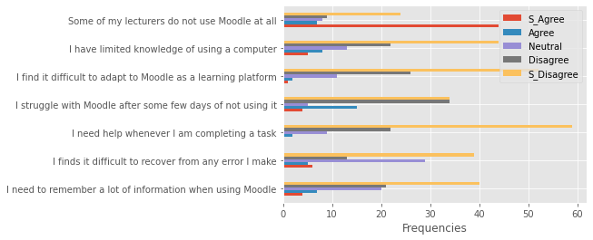

```python
answers = {'S_Agree': [4, 6, 0, 4, 1, 5, 44],
           'Agree': [7, 5, 2, 15, 2, 8, 7],
           'Neutral': [20, 29, 9, 5, 11, 13, 8],
           'Disagree': [21, 13, 22, 34, 26, 22, 9],
           'S_Disagree': [40, 39, 59, 34, 52, 44, 24]
          }
df = pd.DataFrame(answers, columns=['S_Agree', 'Agree', 'Neutral', 'Disagree', 'S_Disagree' ],
                           index = ['I need to remember a lot of information when using Moodle',
                                    'I finds it difficult to recover from any error I make',
                                    'I need help whenever I am completing a task',
                                    'I struggle with Moodle after some few days of not using it',
                                    'I find it difficult to adapt to Moodle as a learning platform',
                                    'I have limited knowledge of using a computer',
                                    'Some of my lecturers do not use Moodle at all'])

plt.style.use('ggplot')
df.plot.barh()
plt.xlabel('Frequencies')
plt.show()
```